# Becsléselmélet

## Az előző részek tartalmából

A legutóbbi alkalommal megnéztük, hogyan számítjuk ki:

- a mintaátlagot (\(\overline{X}\))
- a k. t. szórást (\(s^{*}\))

Ehhez tegyük hozzá a relatív gyakoriságot:

- \(p = \frac{k}{N}\)

## Becslések

Ezek a kiszámított statisztikák becslések:

- a mintaátlag a várható értéké
- a k.t. szórás az elméleti szórásé
- a relatív gyakoriság a valószínűségeké

## Becslések

Ezek a kiszámított statisztikák becslések:

- a mintaátlag a várható értéké: \(\overline{X} \Rightarrow E(\xi)\)
- a k.t. szórás az elméleti szórásé \(s^{*} \Rightarrow D(\xi)\)
- a relatív gyakoriság a valószínűségeké \(p \Rightarrow p_i\)

## Becslések

Ezek a kiszámított statisztikák becslések:

- a mintaátlag a várható értéké: \(\overline{X} \Rightarrow \mu\)
- a k.t. szórás az elméleti szórásé \(s^{*} \Rightarrow \sigma\)
- a relatív gyakoriság a valószínűségeké \(p \Rightarrow p_i\)

## Becslések

Ezek a kiszámított statisztikák becslések:

- a mintaátlag a várható értéké: \(\overline{X} \Rightarrow \mu\)
- a k.t. szórás az elméleti szórásé \(s^{*} \Rightarrow \sigma\)
- a relatív gyakoriság a valószínűségeké \(p \Rightarrow p_i\)

Mivel a becslés eredménye egy-egy szám, ezeket **pontbecslésnek** nevezzük

## A pontbecslések változók

Tegyük fel, hogy van egy 10 milliós populációnk, amelyben

- a magasság várható értéke 170 cm, szórása 10 cm
- és a populáció 25%-a szereti a vaníliafagylaltot.

Ha ebből a populációból 100 elemű véletlen mintákat veszünk, a fenti értékekre adott becsléseink mintáról mintára különböznek:

|  | Elemszám | Átlag | Szórás | Arány |
| --- | --- | --- | --- | --- |
| 1. minta | 100 | 169.89 | 10.86 | 28 |
| 2. minta | 100 | 168.72 | 10.13 | 20 |
| 3. minta | 100 | 170.29 | 9.97 | 18 |

## Ha pedig változók

Akkor rendelkeznek

- várható értékkel
- szórással

Előbbi megegyezik az adott paraméterrel (várható értékkel, szórással, valószínűséggel) ⇒ **torzítatlan**

Utóbbit nevezzük az adott becslés **standard hibájának**.

## Mai célunk

A pontbecsléshez megadni egy **intervallumot**, amelybe a becsülni kívánt paraméter **kellően nagy valószínűséggel** beleesik.

- Ezt az intervallumot **konfidenciaintervallumnak**,
- alsó és felső határát **konfidenciahatároknak**,
- a kellően nagy valószínűséget pedig **konfidenciaszintnek** (1 - α) nevezzük.

A bevett konfidenciaszint társadalomtudományokban 95%, de választhatunk kisebbet vagy nagyobbat is (pl. 90 vagy 99%-ot).

## A mintaátlag eloszlása

Az intervallumbecsléshez azt tudjuk kihasználni, hogy az átlag

- normális eloszlású változó,
- akkor is, ha maga a változó, amelyből számoljuk, nem (**centrális határeloszlás-tétel**)
- amelynek várható értéke egyenlő annak a változónak a várható értékével, amelyből számoljuk,
- szórása pedig \(SE = \frac{\sigma}{\sqrt{N}}\), ahol \(\sigma\) az adott változó szórása.

## A normális eloszlás

## A normális eloszlás

Sok változó, illetve statisztika normális eloszlást követ

Paraméterei:

- várható érték: \(\mu\)
- Szórás: \(\sigma\)

Jelölése: \(N(\mu;\sigma)\)

Sűrűségfüggvénye: az ún. Gauss-görbe

Kiemelt esete: **standard normális eloszlás** - \(N(0; 1)\)

## A Gauss-görbe

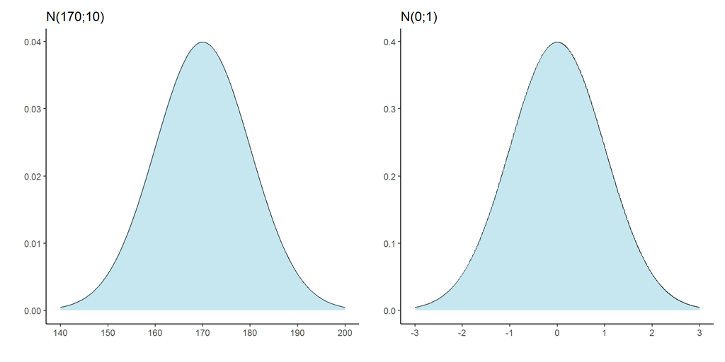

## A N(0;1) táblázat használata

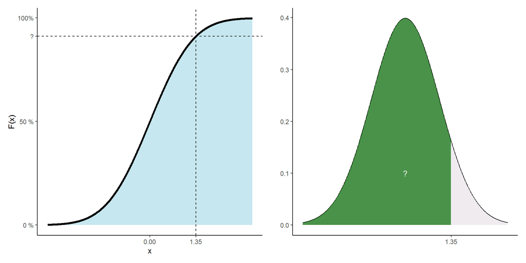

## A N(0;1) táblázat használata

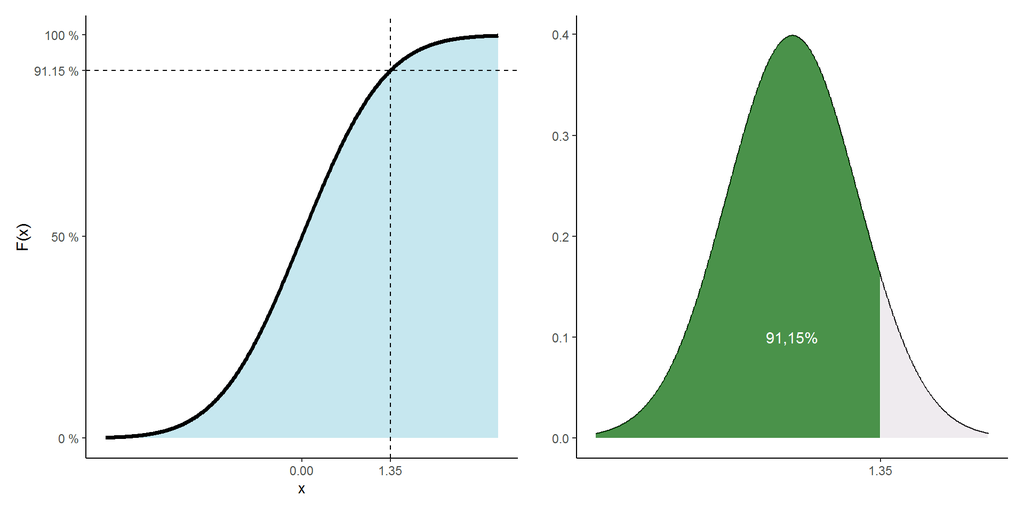

## 1. feladat

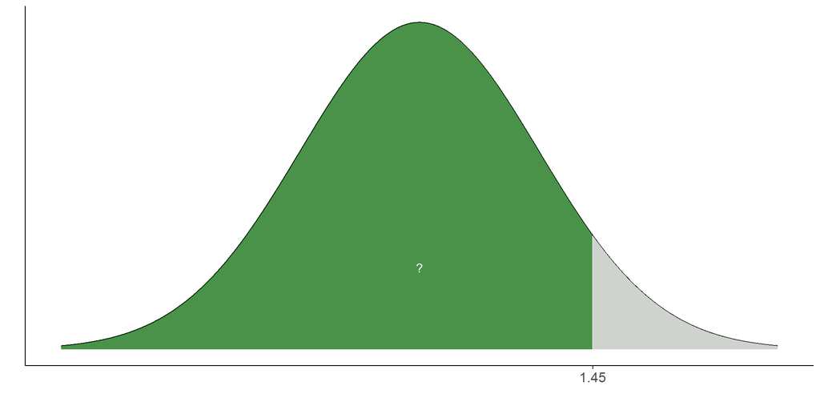

## 1. feladat

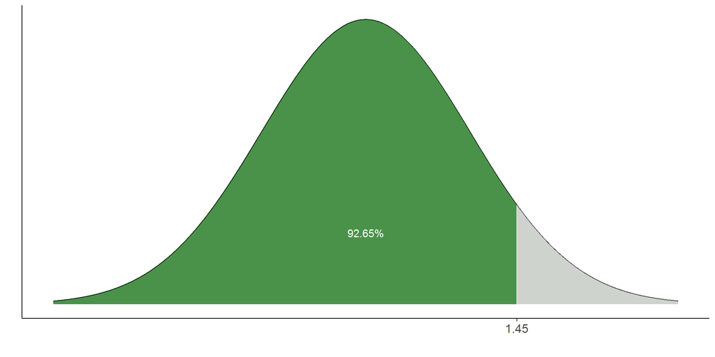

## 2. feladat

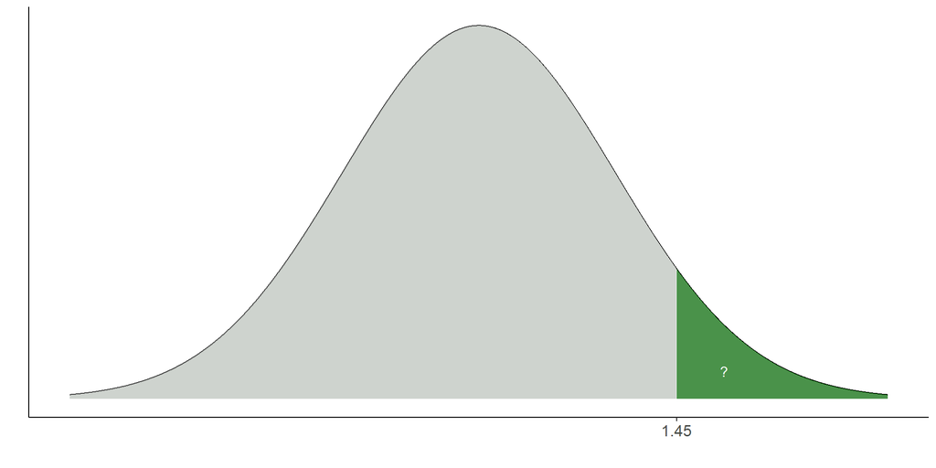

## 2. feladat

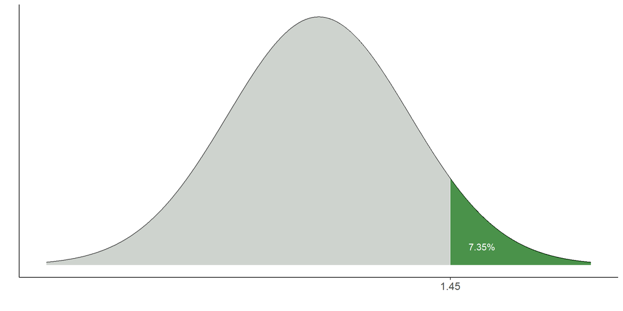

## 3. feladat

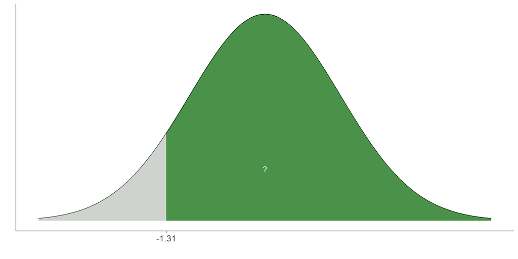

## 3. feladat

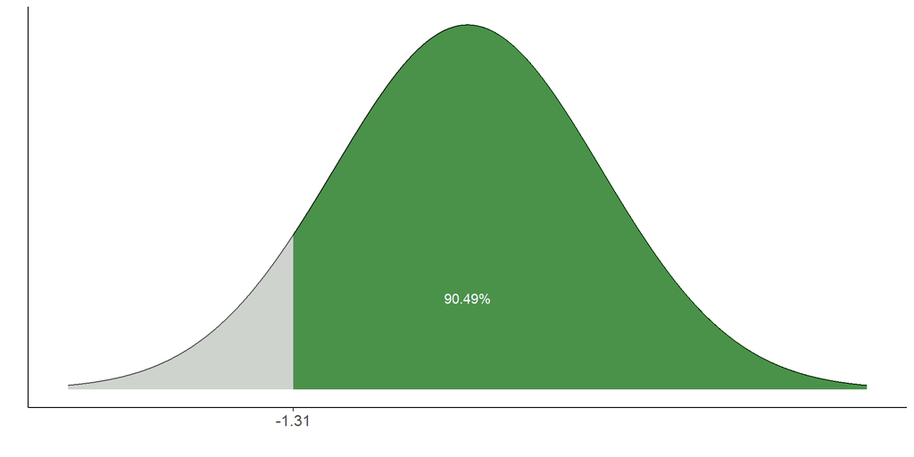

## 4. feladat

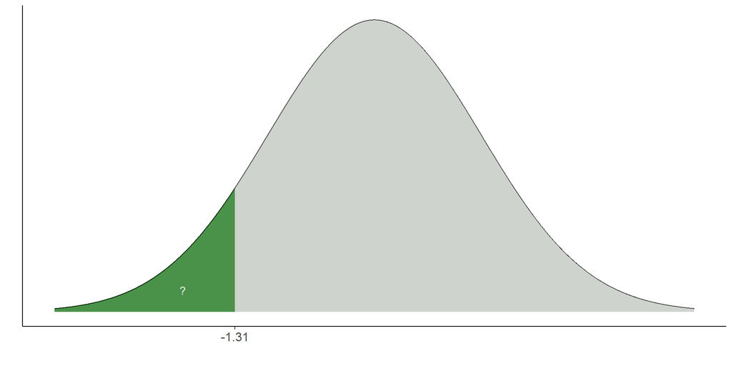

## 4. feladat

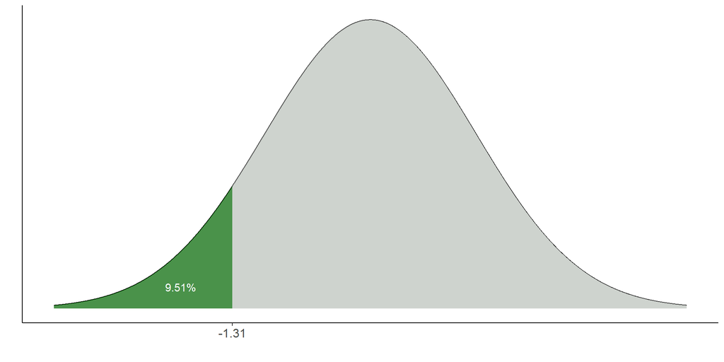

## 5. feladat

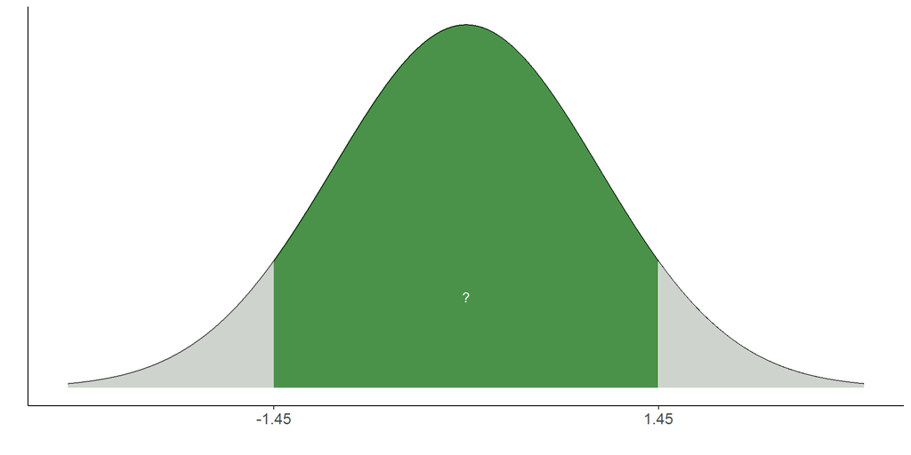

## 5. feladat

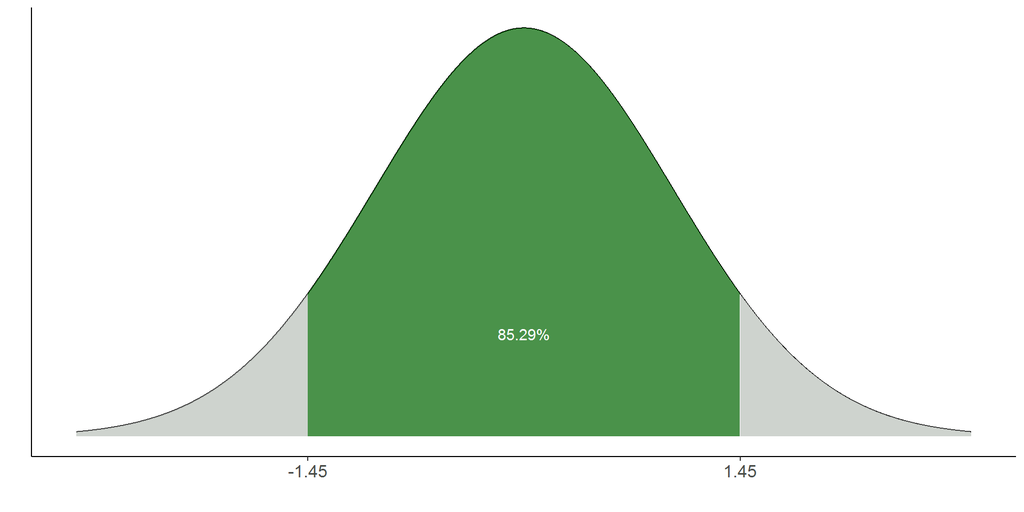

## 6. feladat

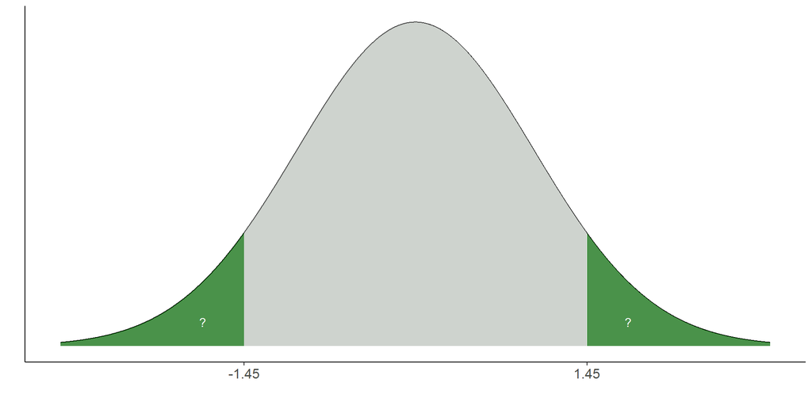

## 6. feladat

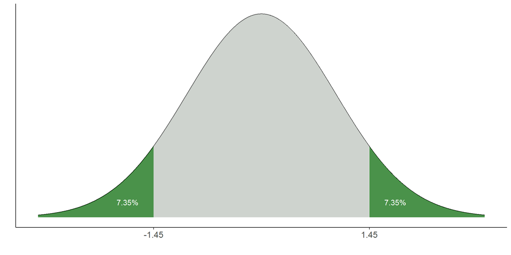

## 7. feladat

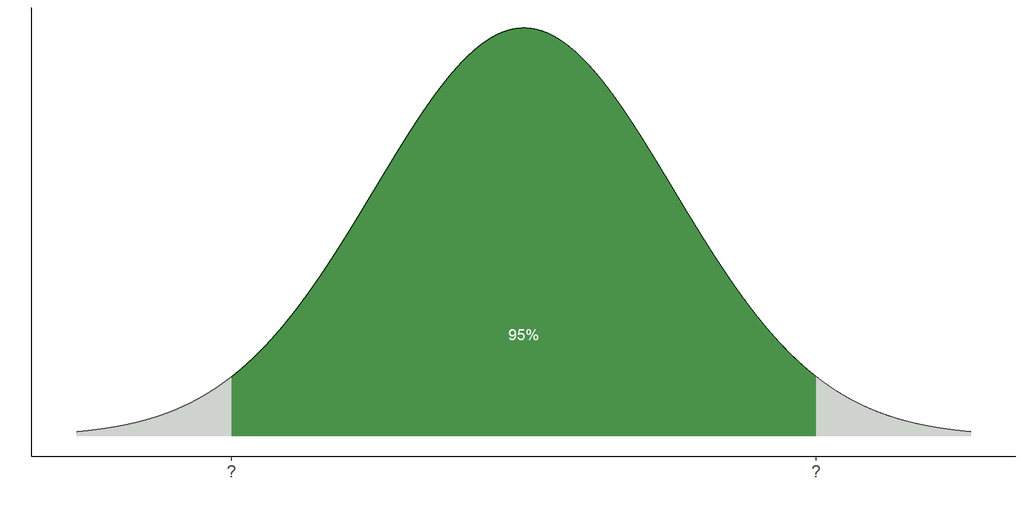

## 7. feladat

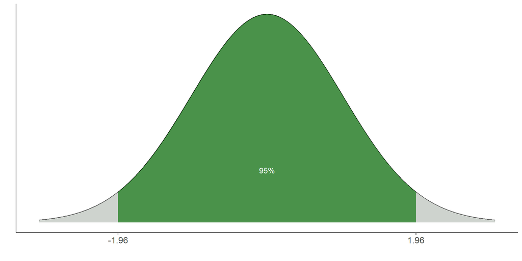

## 8. feladat

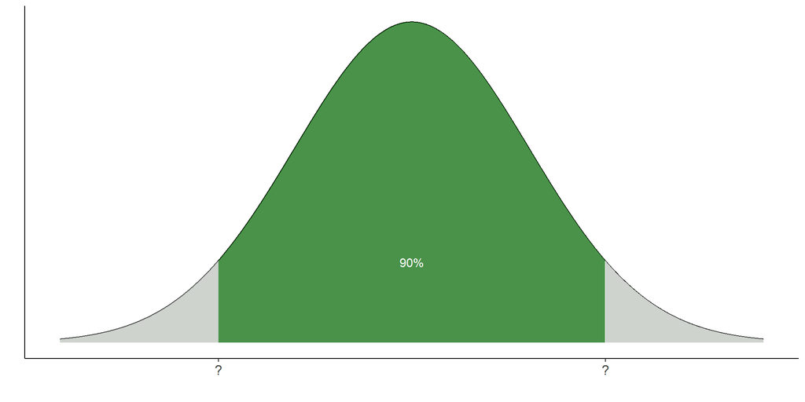

## 8. feladat

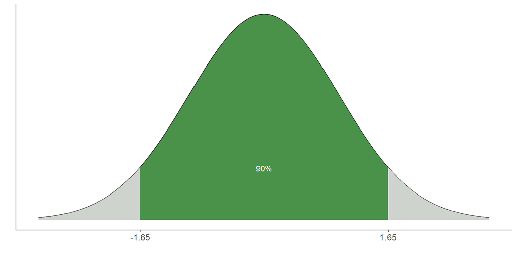

## 9. feladat

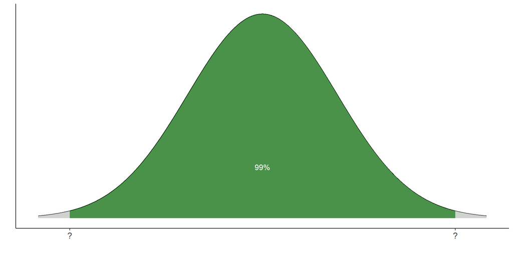

## 9. feladat

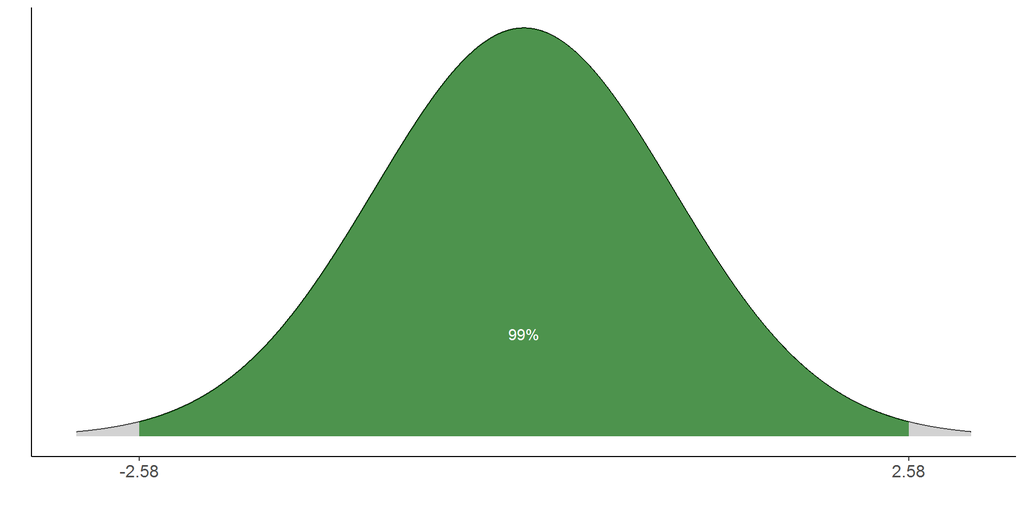

## Táblázatos valószínűség kiszámítása

\[ \begin{aligned} 1-\alpha &= 0,95 \\ \\ \alpha &=0,05 \\ \\ \frac{\alpha}{2} &= 0,025 \\ \\ 1-\frac{\alpha}{2} &= 0,975 \end{aligned} \]

## Konvertálás

## Standardról és vissza

Változó standardizálása: \[z = \frac{x-\mu}{\sigma}\] Standard normális változó visszaalakítása: \[x = \mu + z * \sigma\]

## 10. feladat

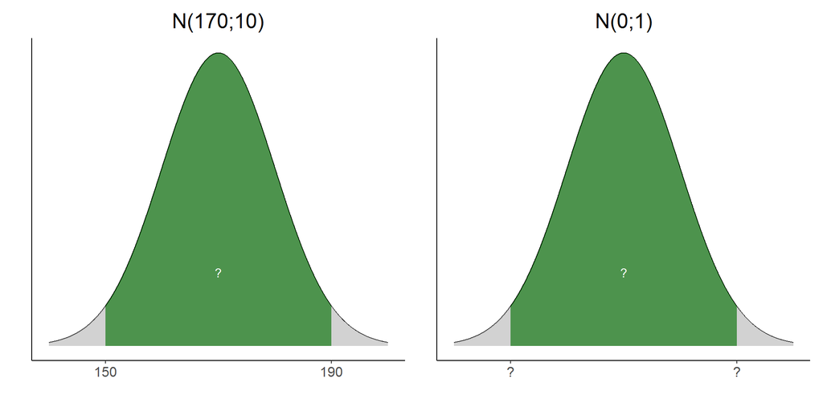

## 10. feladat

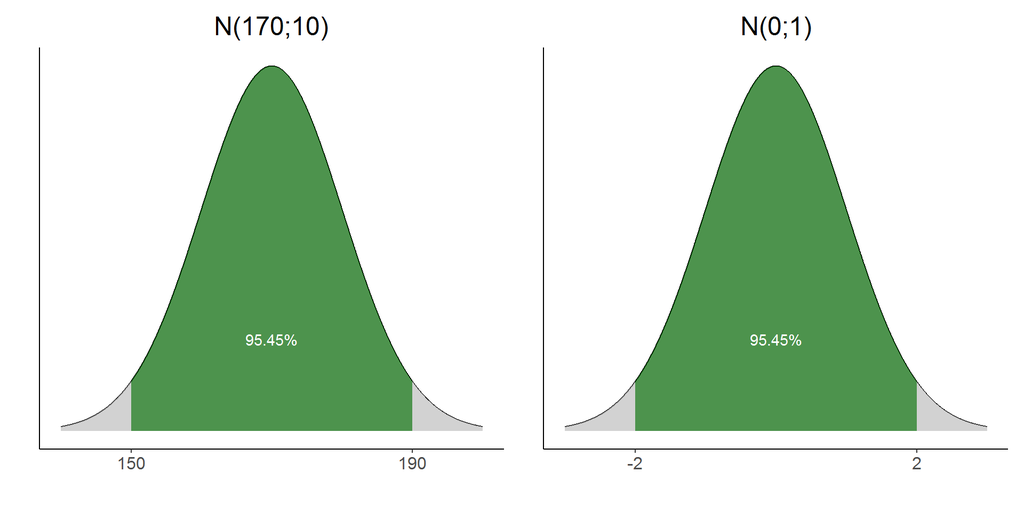

## 11. feladat

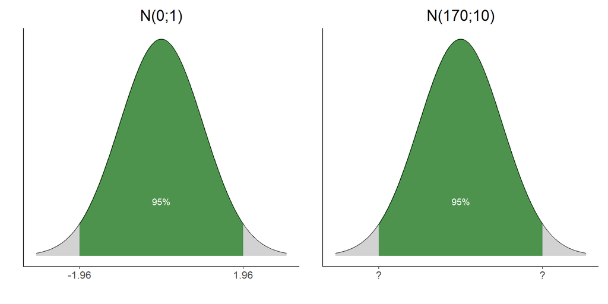

## 11. feladat

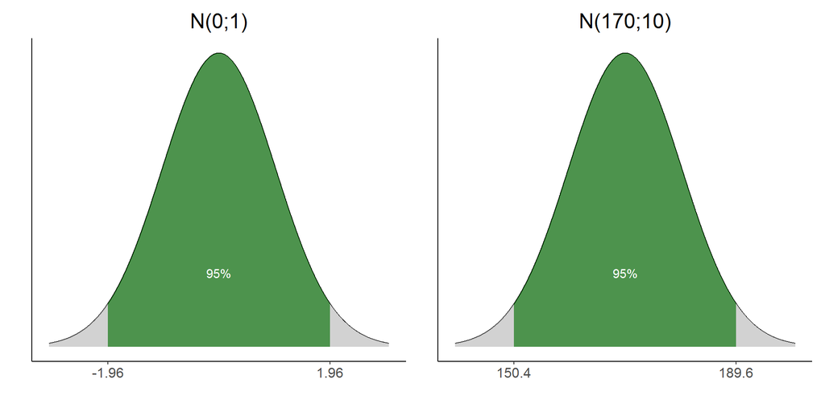

## Vissza az átlaghoz

## Alkalmazzuk rá az új ismereteket!

Fő információk:

- az átlag normális eloszlású változó
- várható értéke a változó várható értéke
- szórása \(SE = \frac{\sigma}{\sqrt{N}}\)

Tegyük fel, hogy van egy változónk (magasság), amelynek várható értéke 170 cm, szórása 10 cm. 100 elemű mintákat veszünk. Milyen értékek közé esik a mintaátlag 95%-os valószínűséggel?

## Az átlag eloszlása

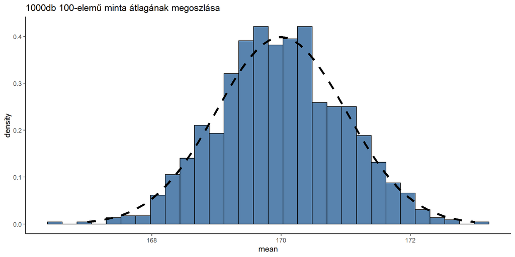

## 12. feladat

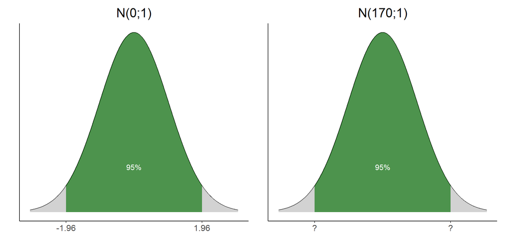

## 12. feladat

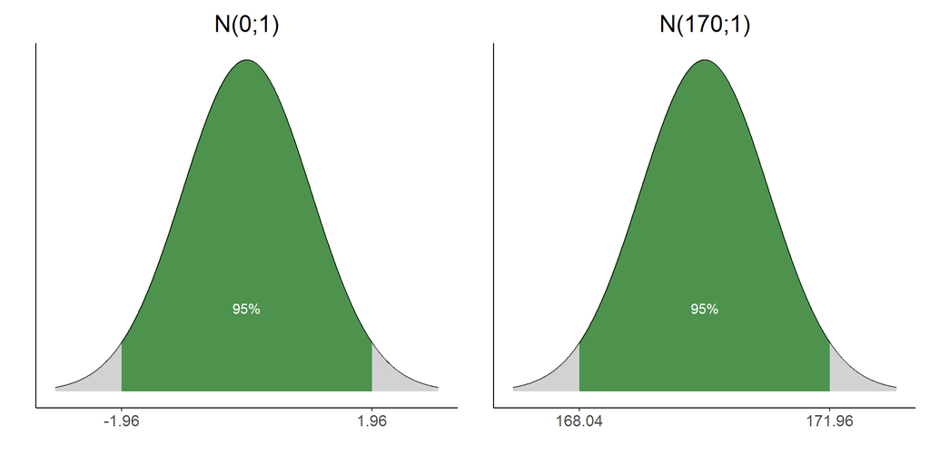

## 1. bökkenő: ismeretlen várható érték

Megoldás:

- Ha a becslés 95%-os valószínűséggel az átlagtól legfeljebb \(1,96*\frac{\sigma}{\sqrt{N}}\) távolságra van
- akkor az átlag a becsléstől 95%-os valószínűséggel legfeljebb ugyanekkora távolságra van

⇒ A becslést alapul véve (e köré) számítjuk ki a konfidenciaintervallumot.

## Megoldás

Képlet:

\[\overline{X} \pm z_{1-\frac{\alpha}{2}}*\frac{\sigma}{\sqrt{N}}\]

Ahol \(\pm z_{1-\frac{\alpha}{2}}\) a st. normális eloszlásnak az \(1-\alpha\) konfidenciaszinthez tartozó határértékei:

- 95%-hoz \(z_{0.975}=1,96\)
- 90%-hoz \(z_{0.95}=1,65\)
- 99%-hoz \(z_{0.995}=2,58\)

## Eredmény

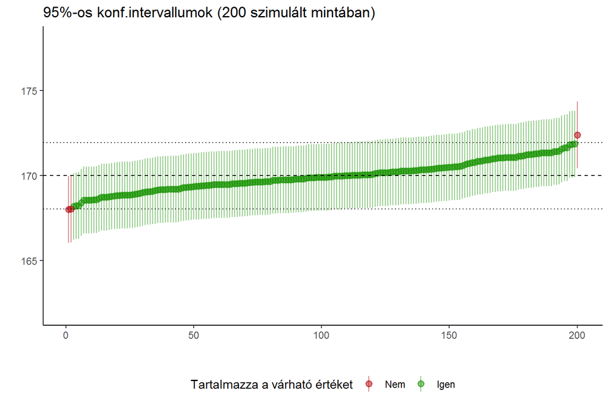

## Eredmény

Ha nagyobb (99%) megbízhatóságot szeretnénk, növelni kell az intervallum szélességét:

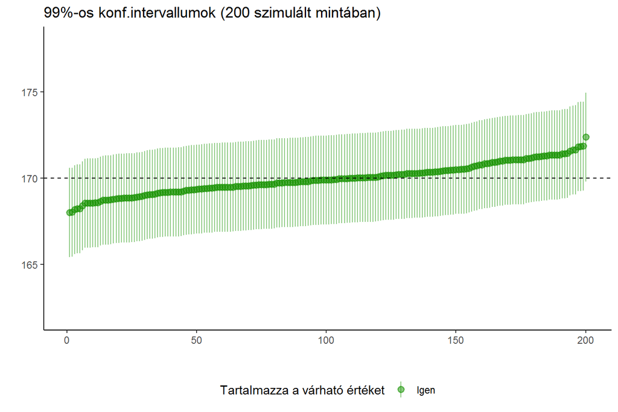

## Eredmény

De, választhatunk kisebb (90%) konfidenciaszintet is:

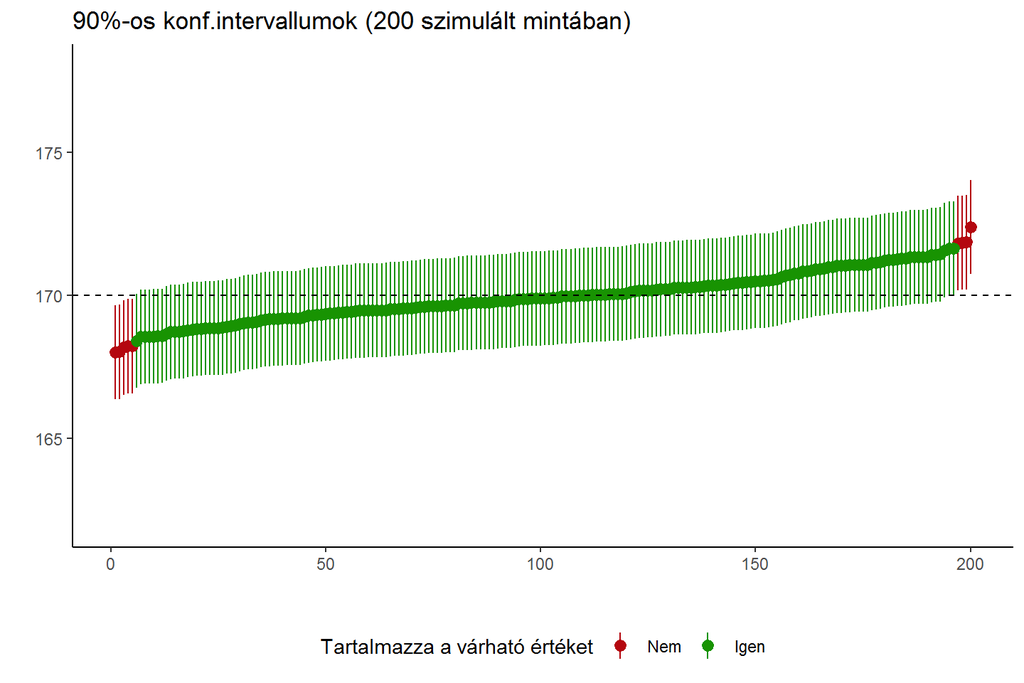

## Intervallumbecslés: feladatok

- \(N=100; \overline{X}=98.4; \sigma=10; 1-\alpha=0.95\)
- \(N=200; \overline{X}=168.3; \sigma=10; 1-\alpha=0.90\)
- \(N=50; \overline{X}=13.5; \sigma=5; 1-\alpha=0.99\)

## Intervallumbecslés: 1. feladat

\[\overline{X} \pm z_{1-\frac{\alpha}{2}}*\frac{\sigma}{\sqrt{N}}\]

\[98.4 \pm 1.96*\frac{10}{\sqrt{100}}=?\]

## Intervallumbecslés: 1. feladat

\[\overline{X} \pm z_{1-\frac{\alpha}{2}}*\frac{\sigma}{\sqrt{N}}\]

\[98.4 \pm 1.96*\frac{10}{\sqrt{100}}=98.4 \pm 1.96\]

## Intervallumbecslés: 1. feladat

\[\overline{X} \pm z_{1-\frac{\alpha}{2}}*\frac{\sigma}{\sqrt{N}}\]

\[98.4 \pm 1.96*\frac{10}{\sqrt{100}}= [96.44; 100.36]\]

## Intervallumbecslés: 2. feladat

\[\overline{X} \pm z_{1-\frac{\alpha}{2}}*\frac{\sigma}{\sqrt{N}}\]

\[168.3 \pm 1.65*\frac{10}{\sqrt{200}}=?\]

## Intervallumbecslés: 2. feladat

\[\overline{X} \pm z_{1-\frac{\alpha}{2}}*\frac{\sigma}{\sqrt{N}}\]

\[168.3 \pm 1.65*\frac{10}{\sqrt{200}}=168.3 \pm 1.17\]

## Intervallumbecslés: 2. feladat

\[\overline{X} \pm z_{1-\frac{\alpha}{2}}*\frac{\sigma}{\sqrt{N}}\]

\[168.3 \pm 1.65*\frac{10}{\sqrt{200}}= [167.13; 169.47]\]

## Intervallumbecslés: 3. feladat

\[\overline{X} \pm z_{1-\frac{\alpha}{2}}*\frac{\sigma}{\sqrt{N}}\]

\[13.5 \pm 2.58*\frac{5}{\sqrt{50}}=?\]

## Intervallumbecslés: 3. feladat

\[\overline{X} \pm z_{1-\frac{\alpha}{2}}*\frac{\sigma}{\sqrt{N}}\]

\[13.5 \pm 2.58*\frac{5}{\sqrt{50}}=13.5 \pm 1.82\]

## Intervallumbecslés: 3. feladat

\[\overline{X} \pm z_{1-\frac{\alpha}{2}}*\frac{\sigma}{\sqrt{N}}\]

\[13.5 \pm 2.58*\frac{5}{\sqrt{50}}= [11.68; 15.32]\]

## 2. bökkenő: becsült szórás

- \(\sigma\) nem ismert, ezért \(s^{*}\)-ot használjuk
- Normális eloszlás helyett Student-féle t-eloszlás
- egy paramétere van: df

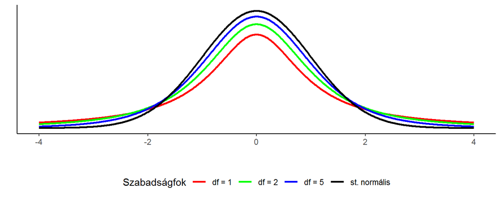

## Az új képlet

\[\overline{X} \pm t_{df;1-\frac{\alpha}{2}}*\frac{s^{\ast}}{\sqrt{N}}\]

- \(t_{1-\frac{\alpha}{2}}\) a t-eloszlásnak az \(1-\alpha\) konfidenciaszintnek és \(df\) szabadságfoknak megfelelő értéke
- a Student-féle t-eloszlás táblázatában
- az \(1-\frac{\alpha}{2}\) oszlopban és
- a \(df=N-1\) sorban találjuk

## Intervallumbecslés becsült szórással: feladatok

- \(N=121; \overline{X}=98.4; s^{*}=9.8; 1-\alpha=0.95\)
- \(N=30; \overline{X}=168.3; s^{*}=10.4; 1-\alpha=0.90\)
- \(N=100; \overline{X}=13.5; s^{*}=5.6; 1-\alpha=0.99\)

## Intervallumbecslés: 1. feladat

\[\overline{X} \pm t_{df;1-\frac{\alpha}{2}}*\frac{s^{\ast}}{\sqrt{N}}\]

\[98.4 \pm 1.98*\frac{9.8}{\sqrt{121}}=?\]

## Intervallumbecslés: 1. feladat

\[\overline{X} \pm t_{df;1-\frac{\alpha}{2}}*\frac{s^{\ast}}{\sqrt{N}}\]

\[98.4 \pm 1.98*\frac{9.8}{\sqrt{121}}=98.4 \pm 1.76\]

## Intervallumbecslés: 1. feladat

\[\overline{X} \pm t_{df;1-\frac{\alpha}{2}}*\frac{s^{\ast}}{\sqrt{N}}\]

\[98.4 \pm 1.98*\frac{9.8}{\sqrt{121}}= [96.64; 100.16]\]

## Intervallumbecslés: 2. feladat

\[\overline{X} \pm t_{df;1-\frac{\alpha}{2}}*\frac{s^{\ast}}{\sqrt{N}}\]

\[168.3 \pm 1.70*\frac{10.4}{\sqrt{30}}=?\]

## Intervallumbecslés: 2. feladat

\[\overline{X} \pm t_{df;1-\frac{\alpha}{2}}*\frac{s^{\ast}}{\sqrt{N}}\]

\[168.3 \pm 1.70*\frac{10.4}{\sqrt{30}}=168.3 \pm 3.23\]

## Intervallumbecslés: 2. feladat

\[\overline{X} \pm t_{df;1-\frac{\alpha}{2}}*\frac{s^{\ast}}{\sqrt{N}}\]

\[168.3 \pm 1.70*\frac{10.4}{\sqrt{30}}= [165.07; 171.53]\]

## Intervallumbecslés: 3. feladat

\[\overline{X} \pm t_{df;1-\frac{\alpha}{2}}*\frac{s^{\ast}}{\sqrt{N}}\]

\[13.5 \pm 2.66*\frac{5.6}{\sqrt{100}}=?\]

## Intervallumbecslés: 3. feladat

\[\overline{X} \pm t_{df;1-\frac{\alpha}{2}}*\frac{s^{\ast}}{\sqrt{N}}\]

\[13.5 \pm 2.66*\frac{5.6}{\sqrt{100}}=13.5 \pm 1.49\]

## Intervallumbecslés: 3. feladat

\[\overline{X} \pm t_{df;1-\frac{\alpha}{2}}*\frac{s^{\ast}}{\sqrt{N}}\]

\[13.5 \pm 2.66*\frac{5.6}{\sqrt{100}}= [12.01; 14.99]\]

## Intervallumbecslés arányra

## Az arány eloszlása

- visszatevés nélküli mintavétel esetén a darabszám és az arány **hipergeometrikus** eloszlást követ

\[E(\xi)=n*\frac{K}{N}\] \[D(\xi)=\sqrt{n*\frac{K}{N}*(1-\frac{K}{N})*\frac{N-n}{N-1}}\]

Jelöljük \(\frac{K}{N}\)-t \(p\)-vel!

## Az arány eloszlása

- visszatevés nélküli mintavétel esetén a darabszám és az arány **hipergeometrikus** eloszlást követ

\[E(\xi)=n* p\] \[D(\xi)=\sqrt{n* p*(1-p)*\frac{N-n}{N-1}}\]

Nézzük az utolsó tagot!

## Az a bizonyos utolsó tag

\[\frac{N-n}{N-1}\]

Nagy populáció (N), és ahhoz képest kis minták (n) esetében ez nagyon közel van az 1-hez.

Pl. 10 milliós populáció és

- n = 100 fő ⇒ 1.0000
- n = 200 fő ⇒ 1.0000
- n = 500 fő ⇒ 1.0000
- n = 1000 fő ⇒ 0.9999
- n = 2000 fő ⇒ 0.9998

## Binomiálissal való közelítés

Ha kicsi a minta, még ha visszatevéses is a mintavétel, aligha kerül be valaki kétszer

\[E(\xi)=n* p\] \[D(\xi)=\sqrt{n* p*(1-p)}\]

Ez így darabszám! Az arányhoz osszuk el a mintanagysággal (itt: \(n\))!

## Binomiálissal való közelítés

Ha kicsi a minta, még ha visszatevéses is a mintavétel, aligha kerül be valaki kétszer

\[E(\xi)=\frac{n* p}{n}=p\] \[D(\xi)=\frac{\sqrt{n* p*(1-p)}}{n}\]